# GIS 712: Environmental Earth Observation and Remote Sensing

## Exploring Planet imagery for water classification—comparing PlanetScope and RapidEye

[figure not shown]

The PlanetScope satellite constellation consists of multiple launches of groups of individual “small-satellites” (~200+ in total). Planet's on-orbit capacity is constantly improving in capability or quantity, with technology improvements deployed at a rapid pace. Each PlanetScope satellite is a CubeSat 3U form factor (10 cm by 10 cm by 30 cm). The complete PlanetScope is able to image the entire Earth every day (equating to a daily collection capacity of ~200 million km²/day).

The RapidEye satellite constellation consisted of five satellites that were able to collect over 6 million square kilometers of data per day at 6.5 meter GSD (at nadir). Each satellite measured less than one cubic meter and weighs 150 kg. These satellites were decomissioned in February 2020.

In this in-class and homework data activity we will continue to work on the Albemarle-Pamlico sound Peninsula/the Alligator River Basin, a coastal area in NC that is experiencing tree dieback (a.k.a. a ‘ghost forest’).

We will be working with surface reflectance of PlanetScope and RapidEye OrthoTiles.

### Planet Surface reflectance

From Planet's product guide:

*"Planet’s Surface Reflectance (SR) Product is derived from the standard Analytic Product (Radiance) and is processed to top-of-atmosphere reflectance and then atmospherically corrected to bottom-of-atmosphere reflectance. This product ensures consistency across localized atmospheric conditions, minimizing uncertainty in spectral response across time and location."*

*Surface Reflectance is available for all orthorectified scenes produced by radiometrically calibrated sun-synchronous orbit Dove and RapidEye satellites. The Surface Reflectance product is available in the API as the ‘analytic_sr’ asset under the PSScene4Band, PSOrthoTile, and REOrthoTile Itemtypes."*

### Planet Scope OrthoTiles

From Planet's website:

*"The PlanetScope Analytic Ortho Tile product is orthorectified, multispectral data from the satellite constellation. Analytic products are calibrated multispectral imagery products that have been processed to allow analysts to derive information products for data science and analytics. This product is designed for a wide variety of applications that require imagery with an accurate geolocation and cartographic projection. It has been processed to remove distortions caused by terrain and can be used for many data science and analytic applications. It eliminates the perspective effect on the ground (not on buildings), restoring the geometry of a vertical shot. The orthorectified visual imagery is optimal for value-added image processing including vegetation indices, land cover classifications, etc. In addition to orthorectification, the imagery has radiometric corrections applied to correct for any sensor artifacts and transformation to at- sensor radiance."*

From Planet's product guide:

[figure not shown]

### RapidEye OrthoTiles

From Planet's website:

*"The RapidEye Analytic Ortho Tile product is orthorectified, multispectral data from the RapidEye satellite constellation. This product is designed for a wide variety of applications that require imagery with an accurate geolocation and cartographic projection. It has been processed to remove distortions caused by terrain and can be used for many data science and analytic applications. It eliminates the perspective effect on the ground (not on buildings), restoring the geometry of a vertical shot. The orthorectified imagery is optimal for value-added image processing including vegetation indices, land cover classifications, etc. In addition to orthorectification, the imagery has radiometric corrections applied to correct for any sensor artifacts and transformation to at-sensor radiance."*

### More information can be found here:

https://www.planet.com/company/resources/

## OBJECTIVES:

1. Learn how to source Planet imagery—if you don't already know this
2. Understand the steps required to mosaic multiple PlanetScope and RapidEye OrthoTiles
3. Understand how to employ Planet's surface reflectance orthotiles for water classification using band-ratio (Normalized Difference Water Index) combined with Otsu Thresholding.

## 1. Sourcing Planet imagery

Planet API allows you to easily draw a region of interest (ROI), apply filters (e.g. dates, cloud cover, view angle, sensor, area coverage, etc.), and download satellite images. You can explore the API [here](https://www.planet.com/).

You will need to login with your Education and Research Account.

If you haven't already gotten an account, please register [here](https://www.planet.com/markets/education-and-research/) to get your Education and Research account. This account allows you to download up to 5,000 km^2 per month for free. Once you sign up, you should get a notification immediately telling you it may take 1 and up to 2 weeks to get an account/API key. Once you've got an account, information on how to get your API key is available [here](https://support.planet.com/hc/en-us/articles/4572497499421-How-to-get-my-API-key-).

Go to the log on page [here](https://account.planet.com/signin).

Here is an example of what the API looks like:

[figure not shown]

## 2. Mosaic multiple PlanetScope and RapidEye orthotiles

The data that will be used for this exercise is available in the "data/NAME_OF_DATA" folder. The folder contains suface reflectance Orthotiles from PlanetScope and RapidEye Orthotiles. Load the **SR_clip.tiff** images to QGIS. How many do we have?

Do these images cover our entire study area?

We need to merge them (i.e. create an image mosaic).

Before we start working with the images you will probably need to install EarthPy and Skimage to your existing GIS712 conda environment, please do so by running the commands below with your GIS712 environment activated, using your anconda prompt (on PC) or at the terminal (if on Mac):

EarthPy (more info [here](https://pypi.org/project/earthpy/))

$ conda install -c conda-forge earthpy

Skimage (more info [here](https://scikit-image.org/docs/dev/install.html#install-via-conda))

$ conda install scikit-image

```python
# import modules
from glob import glob #here is a very useful package to list files in a folder
import rasterio
from rasterio.merge import merge
from rasterio.plot import show
import matplotlib.pyplot as plt
import earthpy.plot as ep
import earthpy.spatial as es
from skimage.filters import threshold_otsu
import numpy as np
```

2.1 PlanetScope Orthotiles

```python
# list all PlanetScope imgs
PS_imgs = glob(os.path.join("data", "PlanetScope", '*SR_clip*.tif')) # note that we are using 2 wildcards here
# Q What is PS_imgs going to give us?
```

```python
# using an empty list to store the images that we will be reading in with rasterio
PS_src_imgs = []

# lets loop through our list, open and append to PS_src_imgs
for img in PS_imgs:
    PS_src = rasterio.open(img)
    PS_src_imgs.append(PS_src)

# Q: What do you suppose PS_src_imgs will give us here?
```

```python
# now we just need to mosaic the files within the source list using rasterio’s merge function
PS_mosaic, PS_out_trans = merge(PS_src_imgs)
# Read up on rasterio's merge: rasterio.merge.merge function here:
# https://rasterio.readthedocs.io/en/latest/api/rasterio.merge.html
# Q: What is PS_mosaic, PS_out_trans going to give us?
# Q: What data type is PS_mosaic
```

```python
print(PS_mosaic.dtype)
print(PS_mosaic.shape[1])
print(PS_mosaic.shape[2])
```

```
uint16
6780
6638
```

```python
PS_out_trans
```

```
Affine(3.125, 0.0, 392062.5,
       0.0, -3.125, 3974843.75)
```

```python
# Copy the metadata from the 1st file
PS_out_meta = PS_src_imgs[0].meta.copy()
PS_out_meta
```

```
{'driver': 'GTiff',
 'dtype': 'uint16',
 'nodata': 0.0,
 'width': 3984,
 'height': 4944,
 'count': 4,
 'crs': CRS.from_epsg(32618),
 'transform': Affine(3.125, 0.0, 392131.25,
        0.0, -3.125, 3974843.75)}
```

```python
# Update the metadata and use it to save the mosaic
PS_out_meta.update({"driver": "GTiff",
                 "height": PS_mosaic.shape[1],
                 "width": PS_mosaic.shape[2],
                 "transform": PS_out_trans})
```

```python
# create path and name of PS mosaic
PS_path_name = "data/PlanetScope/PS_2019-08-29_mosaic.tif"
with rasterio.open(PS_path_name, "w", **PS_out_meta) as dest:
     dest.write(PS_mosaic)
```

#### A very useful package to vis and manipulate raster and vector data in python is EarthPy.

#### Why?

From the EathPy repo website:

*"Python is a generic programming language designed to support many different applications. Because of this, many commonly performed spatial tasks for science including plotting and working with spatial data take many steps of code. EarthPy builds upon the functionality developed for raster data (rasterio) and vector data (geopandas) in Python"*.

First let's check the bands of the moisaic file individually

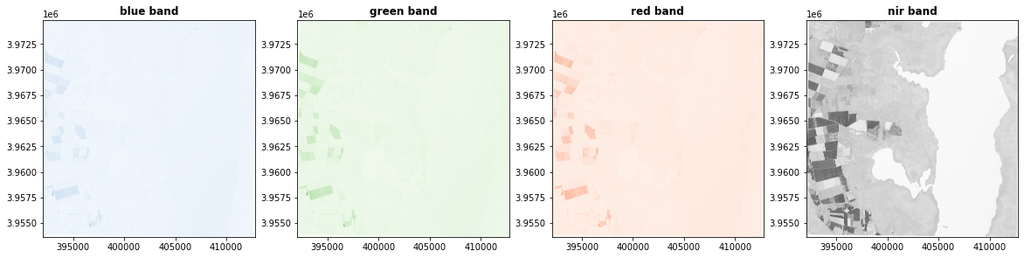

```python
# get PS_final mosaic source
src = rasterio.open("data/PlanetScope/PS_2019-08-29_mosaic.tif")

# create fig and subplots!
fig, (axb, axg, axr, axn) = plt.subplots(1,4, figsize=(20,5))
show((src, 1), ax=axb, cmap='Blues', title='blue band')
show((src, 2), ax=axg, cmap='Greens', title='green band')
show((src, 3), ax=axr, cmap='Reds', title='red band')
show((src, 4), ax=axn, cmap='Greys', title='nir band')
```

Now let's use EarthPy to plot an RGB image!

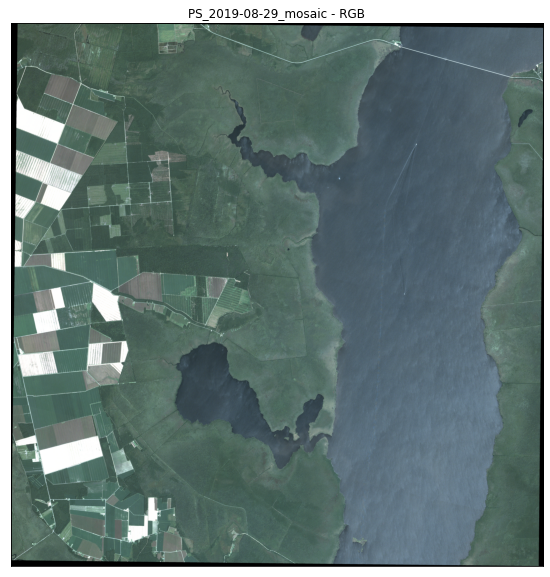

```python
with rasterio.open("data/PlanetScope/PS_2019-08-29_mosaic.tif") as src:
    img_array = src.read()
# Ensure the input array doesn't have nodata values like -9999
# Use stretch = True
ep.plot_rgb(img_array,rgb=(2, 1, 0),stretch=True, title = "PS_2019-08-29_mosaic - RGB")
```

2.2 RapidEye Orthotiles

*In-class*: Using the example code above, can you modify the code as such that you can produce a mosaic of RapidEye images? PLEASE NAME YOUR RASTER LIKE SO "data/RapidEye/RE_2018-10-03_mosaic.tif"

*In-class*: Can you display the final plots of each band (pls note that RapidEye has more bands than PlanetScope, 5 more precisely (Blue, Green, Red, Red Edge, and NIR), you can use cmap='PuRd' for the RedEdge and cmap='Greys' for the NIR band for example) and then plot an RGB image just as we did before?

Water classification using band-ratio (Normalized Difference Water Index) combined with Otsu Thresholding.

The Normalized Difference Water Index (NDWI) is defined as follows:

**NDWI = (GREEN - NIR)/ (GREEN + NIR)**

Values closer to 1 represent water pixels, and values closer -1 represent non-water pixels

```python
# Open the raster files in read mode
PS_final = rasterio.open("data/PlanetScope/PS_2019-08-29_mosaic.tif")
# if you didn't name the RE mosaic as suggested you need to replace the name below to what you named yours
RE_final = rasterio.open("data/RapidEye/RE_2018-10-03_mosaic.tif")
```

```python
# Let's get the metadata
PS_meta = PS_final.profile
RE_meta = RE_final.profile
```

```python
# Let's read the green bands and convert to float
PS_g = PS_final.read(2).astype('f4')
RE_g = RE_final.read(2).astype('f4')
```

```python
# Read the NIR bands and convert to float
PS_nir = PS_final.read(4).astype('f4')
RE_nir = RE_final.read(5).astype('f4')
```

```python
#calculate NDWI
PS_ndwi = (PS_g - PS_nir) / (PS_g + PS_nir)
RE_ndwi = (RE_g - RE_nir) / (RE_g + RE_nir)
```

```
(<Figure size 432x288 with 1 Axes>,
 <AxesSubplot:title={'center':'PS NDWI distribution'}>)
```

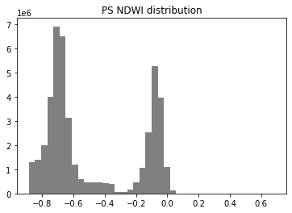

```python
# let's plot using EarthPy functions
ep.hist(PS_ndwi,colors=["grey"],figsize=(6, 4), title="PS NDWI distribution", bins = 40)
```

Let's inspect the histogram above. Based on the histogram, what values should we use as vmin and vmax for plotting the NDWI image?

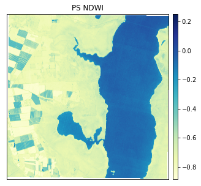

```python
ep.plot_bands(PS_ndwi,
              cmap='YlGnBu',
              scale=False, # whether or not the raster values should be automatically scaled (stretched) between their min and max values.
              vmin=np.nanmin(PS_ndwi), vmax=0.25, # I set vmax after checking the histogram;
              title="PS NDWI",figsize=(5, 5))
plt.show()
```

```
(<Figure size 432x288 with 1 Axes>,
 <AxesSubplot:title={'center':'RE NDWI distribution'}>)
```

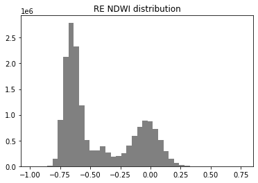

```python
# let's do the same plot using EarthPy functions for the RE data
ep.hist(RE_ndwi ,colors=["grey"],figsize=(6, 4), title="RE NDWI distribution", bins = 40)
```

Similarly, let's inspect the RE histogram. What min and max values should we use to plot the RE NDWI image?

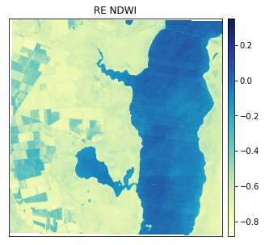

```python
ep.plot_bands(RE_ndwi ,
              cmap='YlGnBu',
              scale=False,
              vmin=np.nanmin(PS_ndwi), vmax=0.35, # I set vnax after checking the histogram;
              title="RE NDWI",figsize=(5, 5))
plt.show()
```

From the histograms, we have a bimodal distribution of the pixels. But how do we separate these two classes (water and non-water pixels)?

We can use thresholding techniques to create a binary image. For this exercise, we will use Otsu threshold from the scikit-image module.

- If the NDWI pixel value is greater than the threshold: the corresponding output pixel is marked as white (water)
- If the NDWI pixel value is less or equal to the threshold: the corresponding output pixel is marked as black (non-water)

To automatically used Otsu Threshold, we need 4 basic steps:  
(1) Process the input image  
(2) Obtain the image histogram (distribution of pixels)  
(3) Compute the threshold value  
(4) Replot the image pixels into those 2 regions, where the NDWI value is greater than the threshold (water/white) and lower than the threshold (not water/black)

The method produces the new image by segmenting the pixels accouting for the variance within each class. The method works well with binary images because the histogram of such images contains two clearly expressed peaks (water and non-water).

Here is a good read about the algorithm: http://www.labbookpages.co.uk/software/imgProc/otsuThreshold.html

```python
# Otsu Threshold
PS_otsu = threshold_otsu(PS_ndwi[~np.isnan(PS_ndwi)])
RE_otsu = threshold_otsu(RE_ndwi[~np.isnan(RE_ndwi)])
# ~np.isnan returns an array where True represents all the non-NaN values in
# PS_ndwi and False represents the NaN values.
```

Q: What Otsu thresholds did we get? Go back to the PS and RE histograms, do these threshold values make sense?

```python
# Global Binary images
PS_binary = PS_ndwi > PS_otsu
PS_binary = PS_binary.astype(int) #zeros or ones

RE_binary = RE_ndwi > RE_otsu
RE_binary = RE_binary.astype(int) #zeros or ones
```

### Q: Now that you have a binary image, what can you do with it ?

Remember that a binary image only has 0 values (non-water) and 1s (water).

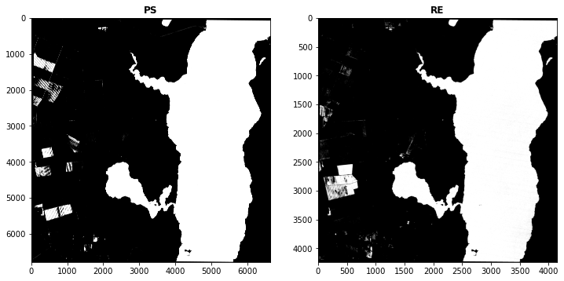

```python
# plot the binary imgs
fig, (axps,axre) = plt.subplots(1,2, figsize=(12, 12))
show(PS_binary, ax=axps,cmap='Greys_r',  title='PS')
show(RE_binary, ax=axre,cmap='Greys_r',  title='RE')
plt.show()
```

Now let's check the image, hist and binary image side by side!

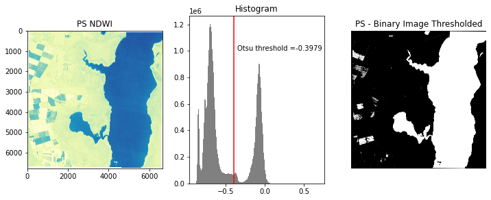

```python
# Plotting images for PS
fig, axes = plt.subplots(ncols=3, figsize=(12,4.5))

# create axis to subpot
ax = axes.ravel()
ax[0] = plt.subplot(1, 3, 1,adjustable='box')
ax[1] = plt.subplot(1, 3, 2)
ax[2] = plt.subplot(1, 3, 3, sharex=ax[0], sharey=ax[0],adjustable='box')

ax[0].imshow(PS_ndwi, cmap='YlGnBu', vmin=np.nanmin(PS_ndwi), vmax=0.25)
ax[0].set_title('PS NDWI')

ax[1].hist(PS_ndwi.ravel(),color = 'grey', bins=256)
ax[1].set_title('Histogram')
ax[1].axvline(PS_otsu, color='r')
ax[1].annotate('Otsu threshold ={0}'.format(str(round(PS_otsu,4))), xy=(-0.35, 1E6))

ax[2].imshow(PS_binary, cmap=plt.cm.gray)
ax[2].set_title('PS - Binary Image Thresholded')
ax[2].axis('off')

plt.show()
```

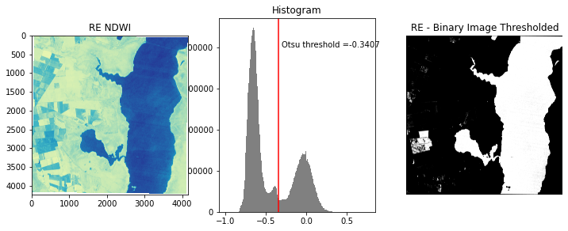

```python
# Plotting images for RE
fig, axes = plt.subplots(ncols=3, figsize=(12,4.5))

# create axis to subpot
ax = axes.ravel()
ax[0] = plt.subplot(1, 3, 1,adjustable='box')
ax[1] = plt.subplot(1, 3, 2)
ax[2] = plt.subplot(1, 3, 3, sharex=ax[0], sharey=ax[0],adjustable='box')

ax[0].imshow(RE_ndwi, cmap='YlGnBu', vmin=np.nanmin(RE_ndwi), vmax=0.25)
ax[0].set_title('RE NDWI')

ax[1].hist(RE_ndwi.ravel(),color = 'grey', bins=256)
ax[1].set_title('Histogram')
ax[1].axvline(RE_otsu, color='r')
ax[1].annotate('Otsu threshold ={0}'.format(str(round(RE_otsu,4))), xy=(-0.30, 4E5))

ax[2].imshow(RE_binary, cmap=plt.cm.gray)
ax[2].set_title('RE - Binary Image Thresholded')
ax[2].axis('off')

plt.show()
```

## Homework - 8 points

(Q1) Comment on the differences between PlanetScope and RapidEye OrthoTiles. 2 points

(Q2) Using the binary images (from the class exercise: PS_binary and RE_binary), calculate water inundation area for both images, and plot your results with using a bar graph. 2 points

HINT: check the spatial resolution for both products.

(Q3) Using the NDWI images (PS_ndwi and RE_ndwi) separate water from land using a fixed threshold of your choice, try to find an optimum threshold. Comment on the advantages and disadvantages of using the Otsu Threshold. Plot your results by comparing the area obtained from your threshold with the results obtained from Otsu (you can use a bar graph here as well). Plot the binary images side by side (i.e., For PS: Yours vs Otsu and for RE: Yours vs Otsu). 3 points